```python
import pandas as pd #library used for data manipulation and analysis
import numpy as np # library used for working with arrays.
import matplotlib.pyplot as plt # library for plots and visualisations
import seaborn as sns # library for visualisations
%matplotlib inline
import warnings
warnings.simplefilter(action='ignore', category=FutureWarning)
import scipy.stats as stats
```

```python
abtest = pd.read_csv('abtest.csv') #import Dataframe
abtest.head()#review first five data rows
```

|  | user_id | group | landing_page | time_spent_on_the_page | converted | language_preferred |
| --- | --- | --- | --- | --- | --- | --- |
| 0 | 546592 | control | old | 3.48 | no | Spanish |
| 1 | 546468 | treatment | new | 7.13 | yes | English |
| 2 | 546462 | treatment | new | 4.40 | no | Spanish |
| 3 | 546567 | control | old | 3.02 | no | French |
| 4 | 546459 | treatment | new | 4.75 | yes | Spanish |

```python
abtest.info() # To see the data type of each of the variable, number of values entered in each of the variables
```

```
<class 'pandas.core.frame.DataFrame'>
RangeIndex: 100 entries, 0 to 99
Data columns (total 6 columns):
 #   Column                  Non-Null Count  Dtype
---  ------                  --------------  -----
 0   user_id                 100 non-null    int64
 1   group                   100 non-null    object
 2   landing_page            100 non-null    object
 3   time_spent_on_the_page  100 non-null    float64
 4   converted               100 non-null    object
 5   language_preferred      100 non-null    object
dtypes: float64(1), int64(1), object(4)
memory usage: 4.8+ KB
```

```python
import sys #install pandas profiling
!{sys.executable} -m pip install pandas-profiling
```

```python
#import pandas_profiling
import pandas_profiling
```

```python
pandas_profiling.ProfileReport(abtest) #apply pandas profiling
```

[interactive chart not shown]

The E-news Express compared its existing landing page to landing page with new features. The online news portal limited its data collection to 100 landing page visitors: 50 current landing page visitors (the control) and 50 new feature landing page visitors (the treatment). The data collected includes an assigned user ID, control vs treatment, time spent on page, conversion, and the visitors preferred language.

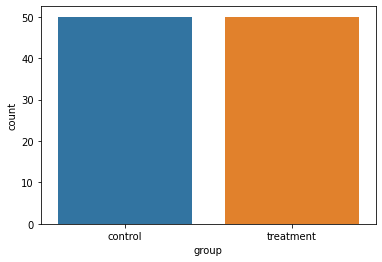

```python
#visualizing the data
sns.countplot(abtest['group']);
```

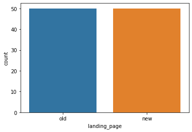

```python
#visualizing the data
sns.countplot(abtest['landing_page']);
```

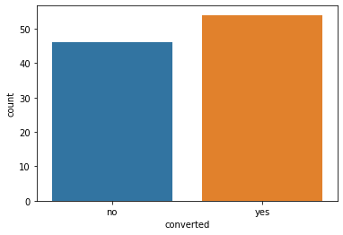

```python
#visualizing the data
sns.countplot(abtest['converted']);
```

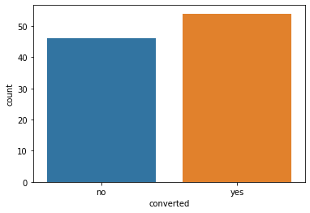

```python
#visualizing the data
sns.countplot(abtest['converted']);
```

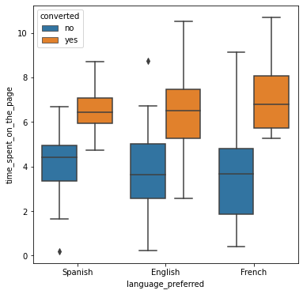

```python
# draw the boxplot for visualization
fig, ax = plt.subplots(figsize = (6,6))
a = sns.boxplot(x= "language_preferred", y = 'time_spent_on_the_page' , data = abtest, hue = 'converted')
plt.show()
```

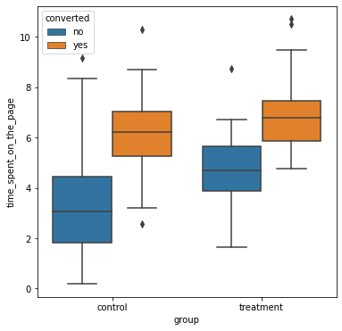

```python
# draw the boxplot for visualization
fig, ax = plt.subplots(figsize = (6,6))
a = sns.boxplot(x= "group", y = 'time_spent_on_the_page' , data = abtest, hue = 'converted')
plt.show()
```

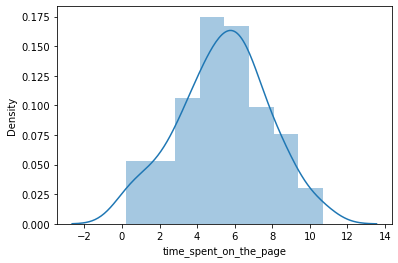

```python
#visualizing the data
sns.distplot(abtest['time_spent_on_the_page'])
```

```python
#preparing the data for visuals and calculating the means & standard deviations.

abtest1 = abtest[abtest['group'] == 'control']

abtest2 = abtest[abtest['group'] == 'treatment']
```

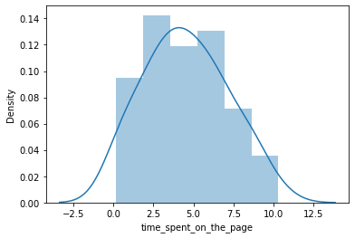

```python
#visualizing the data
sns.distplot(abtest1['time_spent_on_the_page'])
```

The Control group appears normally distributed.

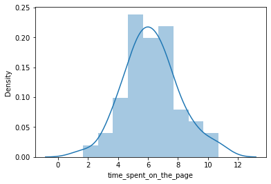

```python
#visualizing the data
sns.distplot(abtest2['time_spent_on_the_page'])
```

The Treatment group appears to be normally distributed.

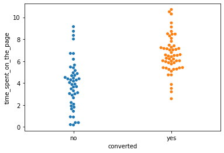

```python
#visualizing the data
sns.swarmplot(data = abtest, x='converted', y='time_spent_on_the_page')
```

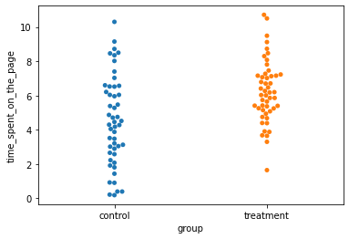

```python
#visualizing the data
sns.swarmplot(data = abtest, x='group', y='time_spent_on_the_page')
```

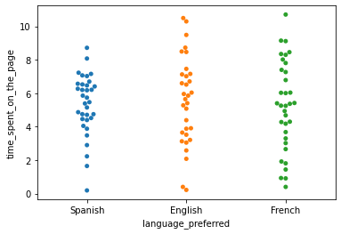

```python
#visualizing the data
sns.swarmplot(data = abtest, x='language_preferred', y='time_spent_on_the_page')
```

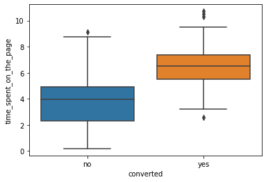

```python
#visualizing the data
sns.boxplot(data = abtest, x='converted', y='time_spent_on_the_page')
```

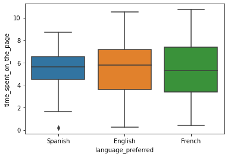

```python
#visualizing the data
sns.boxplot(data = abtest, x='language_preferred', y='time_spent_on_the_page')
```

# Do landing page visitors spend more time on the new landing page (treatment) than the old landing page (control)?

Let μ1, μ2 be the time spend on the old landing page and the time spent on the new landing page respectively.

We will test the null hypothesis

$H_0$: μ1=μ2

against the alternate hypothesis

$H_a$: μ1≠μ2

```python
# find the sample means and sample standard deviations for the two abtest samples
print('The mean time spent on the page for control landing page is ' + str(abtest1['time_spent_on_the_page'].mean()))
print('The mean time spent on the page for treatment landing page is ' + str(abtest2['time_spent_on_the_page'].mean()))
print('The standard deviation of time spent on the page for control landing page is ' + str(round(abtest1['time_spent_on_the_page'].std(), 2)))
print('The standard deviation of time spent on the page for treatment landing page is ' + str(round(abtest2['time_spent_on_the_page'].std(), 2)))
```

```
The mean time spent on the page for control landing page is 4.532400000000001
The mean time spent on the page for treatment landing page is 6.2232
The standard deviation of time spent on the page for control landing page is 2.58
The standard deviation of time spent on the page for treatment landing page is 1.82
```